# 510_Final_Project

Hanna Lu

12/11/2020

#### **Updates Since Last Submission and Responses to Peer Review Comments:**

**Updates Since Last Submission:**

- Focused only on patients who were sent home
- Added six vital sign variables to the analysis
- Added investigation of missing values and outliers in the vital sign variables

**Responses to Peer Review Comments:**

- The data is de-identified. The date of birth and date of death (if applicable) are masked. There is no other information that can easily identify the patient. Nevertheless, the data is restricted.
- The inconsistency in subsetting the data by columns has been fixed.
- About training and test sets, since this project is to identify factors that impact the mortality and to analyze the effect of the impact, it is more explanatory than predictive at this point, and thus no need to split the data into training and test sets. However, our future work will include a prediction part after investigating more variables such as topic modeling results from doctor’s notes, which will require splitting the data into training and test sets.

### **Survival Analysis**

Patients are discharged to different locations such as SNF (skilled nursing facilities), hospice, long-term care hospitals, rehabilitation facilities, and home according to doctors’ judgment of the patients’ health condition at the end of their stay in the hospital. Those who are sent home are considered to be in a steady and safe condition at the end of their hospital stay. However, a significant percentage of patients who are sent home die within 90 days of discharge from the hospital. In this study, we aim to find the mortality risk indicators to help doctors reevaluate their patient discharge decisions in hope of reducing mortality rate among patients who are sent home after their stay in the hospital.

This analysis uses variables from 11 data sets. Some of them are re-engineered. In addition to the demographic and hospital stay information, comorbidity indexes and vital signs are also investigated in this study.

#### Data Source: https://mimic.physionet.org/gettingstarted/access/

Install packages:

```r
library(dplyr)
library(stringr)
library(reshape2)
library(comorbidity)
library(ggplot2)
library(visdat)
library(naniar)
library(survival)
library(survminer)
library(grid)
library(tiff)
```

### IMPORT NOTEEVENTS

A patient can have multiple reports (or doctor’s notes). We hypothesize that the more doctor’s notes, the higher the risk of mortality.But the number of reports is not readily available in the data set.

The following code creates a variable NUM_REPORTS (Number of Reports) from the NOTEEVENTS data set by grouping the data by HADM_ID (Hospital Admission ID) and then counting the number of rows in each group.

```r
filename <- gzfile('Data/NOTEEVENTS.csv.gz','rt')
note <- read.csv(filename)

str(note)
```

```
## 'data.frame':    2083180 obs. of  11 variables:
##  $ ROW_ID     : int  174 175 176 177 178 179 180 181 182 183 ...
##  $ SUBJECT_ID : int  22532 13702 13702 13702 26880 53181 20646 42130 56174 56174 ...
##  $ HADM_ID    : int  167853 107527 167118 196489 135453 170490 134727 114236 163469 189681 ...
##  $ CHARTDATE  : chr  "2151-08-04" "2118-06-14" "2119-05-25" "2124-08-18" ...
##  $ CHARTTIME  : chr  "" "" "" "" ...
##  $ STORETIME  : chr  "" "" "" "" ...
##  $ CATEGORY   : chr  "Discharge summary" "Discharge summary" "Discharge summary" "Discharge summary" ...
##  $ DESCRIPTION: chr  "Report" "Report" "Report" "Report" ...
##  $ CGID       : int  NA NA NA NA NA NA NA NA NA NA ...
##  $ ISERROR    : int  NA NA NA NA NA NA NA NA NA NA ...
##  $ TEXT       : chr  "Admission Date:  [**2151-7-16**]       Discharge Date:  [**2151-8-4**]\n\n\nService:\nADDENDUM:\n\nRADIOLOGIC S"| __truncated__ "Admission Date:  [**2118-6-2**]       Discharge Date:  [**2118-6-14**]\n\nDate of Birth:                    Sex"| __truncated__ "Admission Date:  …
```

```r
# Create a data frame with 2 columns (HADM_ID and NUM_REPORTS) to be joined
# with other data sets
num_reports <- note %>%
  group_by(HADM_ID) %>%
  summarise(NUM_REPORTS = n(),.groups = 'drop') %>%
  select(HADM_ID, NUM_REPORTS)

rm(note)
```

### IMPORT ADMISSIONS

The ADMISSIONS data set contains some demographic information of the patients, as well as hospital admission and discharge information

The following code joins this data set with the Number of Reports data extracted from the NOTEEVENTS data set.

```r
filename <- gzfile('Data/ADMISSIONS.csv.gz','rt')
admissions <- read.csv(filename)

str(admissions)
```

```
## 'data.frame':    58976 obs. of  19 variables:
##  $ ROW_ID              : int  21 22 23 24 25 26 27 28 29 30 ...
##  $ SUBJECT_ID          : int  22 23 23 24 25 26 27 28 30 31 ...
##  $ HADM_ID             : int  165315 152223 124321 161859 129635 197661 134931 162569 104557 128652 ...
##  $ ADMITTIME           : chr  "2196-04-09 12:26:00" "2153-09-03 07:15:00" "2157-10-18 19:34:00" "2139-06-06 16:14:00" ...
##  $ DISCHTIME           : chr  "2196-04-10 15:54:00" "2153-09-08 19:10:00" "2157-10-25 14:00:00" "2139-06-09 12:48:00" ...
##  $ DEATHTIME           : chr  "" "" "" "" ...
##  $ ADMISSION_TYPE      : chr  "EMERGENCY" "ELECTIVE" "EMERGENCY" "EMERGENCY" ...
##  $ ADMISSION_LOCATION  : chr  "EMERGENCY ROOM ADMIT" "PHYS REFERRAL/NORMAL DELI" "TRANSFER FROM HOSP/EXTRAM" "TRANSFER FROM HOSP/EXTRAM" ...
##  $ DISCHARGE_LOCATION  : chr  "DISC-TRAN CANCER/CHLDRN H" "HOME HEALTH CARE" "HOME HEALTH CARE" "HOME" ...
##  $ INSURANCE           : chr  "Private" "Medicare" "Medicare" "Private" ...
##  $ LANGUAGE            : chr  "" "" "ENGL" "" ...
##  $ RELIGION            : chr  "UNOBTAINABLE" "CATHOLIC" "CATHOLIC" "PROTESTANT QUAKER" ...
##  $ MARITAL_STATUS      : chr  "MARRIED" "MARRIED" "MARRIED" "SINGLE" ...
##  $ ETHNICITY           : chr  "WHITE" "WHITE" "WHITE" "WHITE" ...
##  $ EDREGTIME           : chr  "2196-04-09 10:06:00" "" "" "" ...
##  $ EDOUTTIME           : chr  "2196-04-09 13:24:00" "" "" "" ...
##  $ DIAGNOSIS           : chr  "BENZODIAZEPINE OVERDOSE" "CORONARY ARTERY DISEASE\\CORONARY ARTERY BYPASS GRAFT/SDA" "BRAIN MASS" "INTERIOR MYOCARDIAL INFARCTION" ...
##  $ HOSPITAL_EXPIRE_FLAG: int  0 0 0 0 0 0 0 0 0 1 ...
##  $ HAS_CHARTEVENTS_DATA: int  1 1 1 1 1 1 1 1 1 1 ...
```

```r
# Merge admissions and num_reports (inner join):
adm = merge(admissions, num_reports, by='HADM_ID')

rm(admissions)
```

### IMPORT ICUSTAYS

This data set contains the ICU stay information such as the first and last ICU unit the patient stayed in, in and out time, and length of stay.

A patient can be admitted to different ICU units during their stay in the hospital. We hypothesize that the last ICU unit the patient stayed in may be related to the patient’s risk of mortality since it carries the information about the patient’s latest condition. ICU length of stay may have an impact on the mortality risk as well.

```r
filename <- gzfile('Data/ICUSTAYS.csv.gz','rt')
icu <- read.csv(filename)

str(icu)
```

```
## 'data.frame':    61532 obs. of  12 variables:
##  $ ROW_ID        : int  365 366 367 368 369 370 371 372 373 374 ...
##  $ SUBJECT_ID    : int  268 269 270 271 272 273 274 275 276 277 ...
##  $ HADM_ID       : int  110404 106296 188028 173727 164716 158689 130546 129886 135156 171601 ...
##  $ ICUSTAY_ID    : int  280836 206613 220345 249196 210407 241507 254851 219649 206327 272866 ...
##  $ DBSOURCE      : chr  "carevue" "carevue" "carevue" "carevue" ...
##  $ FIRST_CAREUNIT: chr  "MICU" "MICU" "CCU" "MICU" ...
##  $ LAST_CAREUNIT : chr  "MICU" "MICU" "CCU" "SICU" ...
##  $ FIRST_WARDID  : int  52 52 57 52 57 52 12 7 57 56 ...
##  $ LAST_WARDID   : int  52 52 57 23 57 52 12 7 57 56 ...
##  $ INTIME        : chr  "2198-02-14 23:27:38" "2170-11-05 11:05:29" "2128-06-24 15:05:20" "2120-08-07 23:12:42" ...
##  $ OUTTIME       : chr  "2198-02-18 05:26:11" "2170-11-08 17:46:57" "2128-06-27 12:32:29" "2120-08-10 00:39:04" ...
##  $ LOS           : num  3.25 3.28 2.89 2.06 1.62 ...
```

```r
# Create two columns for the last ICU unit and total Length of Stay:
icu_last <- icu %>%
  select(HADM_ID, LAST_CAREUNIT, LOS) %>%
  group_by(HADM_ID) %>%
  mutate(LAST_ICU = last(LAST_CAREUNIT)) %>%
  select(HADM_ID, LAST_ICU) %>%
  distinct()

# Merge ICU Unit data with admission data (inner join):
adm_icu <- merge(adm, icu_last, by = 'HADM_ID')

rm(icu)
```

### IMPORT PATIENTS

This data set contains patients’ personal information such as gender, date of birth, and date of death. We need the date of birth variable to calculate the patients’ age, and the date of death variable to create the EVENT column (weather of not a death event occurred) and the Duration column (length of time until a death event occurred) for the survival analysis.

The following code joins this data set with the previous data set.

```r
filename <- gzfile('Data/PATIENTS.csv.gz','rt')
patients <- read.csv(filename)

str(patients)
```

```
## 'data.frame':    46520 obs. of  8 variables:
##  $ ROW_ID     : int  234 235 236 237 238 239 240 241 242 243 ...
##  $ SUBJECT_ID : int  249 250 251 252 253 255 256 257 258 260 ...
##  $ GENDER     : chr  "F" "F" "M" "M" ...
##  $ DOB        : chr  "2075-03-13 00:00:00" "2164-12-27 00:00:00" "2090-03-15 00:00:00" "2078-03-06 00:00:00" ...
##  $ DOD        : chr  "" "2188-11-22 00:00:00" "" "" ...
##  $ DOD_HOSP   : chr  "" "2188-11-22 00:00:00" "" "" ...
##  $ DOD_SSN    : chr  "" "" "" "" ...
##  $ EXPIRE_FLAG: int  0 1 0 0 0 0 0 1 0 0 ...
```

```r
# Merge patients and adm_icu:
df_patient_icu <- merge(adm_icu, patients, by='SUBJECT_ID', all.x = T)

rm(patients)
```

### IMPORT DIAGNOSES_ICD

This data set contains the ICD9_CODE (code for type of diagnosed disease) for each patient. A patient can have multiple ICD9 codes

```r
filename <- gzfile('Data/DIAGNOSES_ICD.csv.gz','rt')
diagnoses <- read.csv(filename)
str(diagnoses)
```

```
## 'data.frame':    651047 obs. of  5 variables:
##  $ ROW_ID    : int  1297 1298 1299 1300 1301 1302 1303 1304 1305 1306 ...
##  $ SUBJECT_ID: int  109 109 109 109 109 109 109 109 109 109 ...
##  $ HADM_ID   : int  172335 172335 172335 172335 172335 172335 172335 172335 172335 172335 ...
##  $ SEQ_NUM   : int  1 2 3 4 5 6 7 8 9 10 ...
##  $ ICD9_CODE : chr  "40301" "486" "58281" "5855" ...
```

```r
diagnoses <- diagnoses[,c("HADM_ID","ICD9_CODE")]

df_com <- merge(df_patient_icu, diagnoses, by = 'HADM_ID', all.x = T)

rm(diagnoses)
```

### COMORBIDITY SCORES

```r
# Charlson comorbidity scores based on ICD-10 diagnostic codes:
df_comorbidity <- comorbidity(x = df_com, id = "HADM_ID", code = "ICD9_CODE",
                             score = "charlson", assign0 = FALSE, icd = 'icd9')

# Remove the last four items from the comorbidity output
df_comorbidity <- df_comorbidity[,!names(df_comorbidity) %in%
                                   c("score", "index","wscore","windex")]

# Remove the icd code column from original data frame:
com_no_icd <- df_com[,names(df_com) != 'ICD9_CODE']

# Remove duplicates from original data frame:
unique_com <- unique(com_no_icd)

# Merge the main dataset and the comorbidity:
com_all <- merge(unique_com, df_comorbidity, by="HADM_ID")

# Remove "DIAGNOSIS":
com_all <- select(com_all, -DIAGNOSIS)
```

### DATA CLEANING

The following code generates the EVENT column (whether or not a patient died within 90 days of discharge from hospital) and the Duration column (time difference between Date of Death and Date of Discharge if the patient died during the following up period. If Date of Death is missing, set it as 300 days)

The following code also removes the patients who are admitted to the hospital as “NEWBORN”, or died within one day after discharge, or died in the hospital.

```r
# Convert DOD (Date of Death) to date format:
com_all$DOD <- as.Date(com_all$DOD, format = '%Y-%m-%d')

df_all <- com_all %>%
  # Identify DODs after 90 days and create Duration column
  mutate(Duration = ifelse(is.na(DOD), 300,
                           (DOD - as.Date(DISCHTIME, format = '%Y-%m-%d %H:%M:%S')))) %>%
  # Create EVENT (death within 90 days of discharge as 1, otherwise 0)
  mutate(EVENT = ifelse(Duration <= 90, 1, 0)) %>%
  # Remove patients who died before discharge or within one day of discharge
  # Remove newborns
  # Remove patients who died in hospital
  filter(Duration >= 1 & ADMISSION_TYPE!='NEWBORN' & HOSPITAL_EXPIRE_FLAG == 0)
```

The following code creates the HOSPITAL_LOS (Hospital Length of Stay, which is time between admission and discharge) and Age(age at time of discharge) columns. It also removes the patients who stayed in the hospital for less than one day, who are under the age of 18, and those who are discharged to places other than home.

```r
df_all <- df_all %>%
  # Create a column for hospital length of stay
  mutate(HOSPITAL_LOS = (as.Date(DISCHTIME, format = '%Y-%m-%d %H:%M:%S') -
                           as.Date(ADMITTIME, format = '%Y-%m-%d %H:%M:%S'))) %>%
  # Remove those who stayed less than 1 day in the hospital
  filter(HOSPITAL_LOS > 1) %>%
  # Create Age at Discharge column from DOB and Discharge time columns
  mutate(age = (as.Date(DISCHTIME, format = '%Y-%m-%d %H:%M:%S') -
                  as.Date(DOB, format = '%Y-%m-%d %H:%M:%S'))/365) %>%
  # Remove those who are under the age of 18:
  filter(age >= 18) %>%
  # Keep only the patients who are sent home
  filter(DISCHARGE_LOCATION == 'HOME')

# If age is greater than 100, code it to 90
# In the MIMIC database, patients older than 89 were coded as 300 years old
df_all$age <- ifelse(df_all$age > 100, 90, round(df_all$age,1))
```

The following code re-groups categorical variables.

```r
# Regroup Marital Status:
df_all <- df_all %>%
  mutate(MARITAL_STATUS_CAT = case_when(
          MARITAL_STATUS == 'SINGLE'                       ~ 'SINGLE',
          MARITAL_STATUS == 'WIDOWED'                      ~ 'WIDOWED',
          MARITAL_STATUS %in% c('MARRIED', 'LIFE PARTNER') ~ 'MARRIED',
          MARITAL_STATUS %in% c('DIVORCED','SEPARATED')    ~ 'DIVORCED',
          TRUE                                             ~ 'UNKNOWN'))

df_all$MARITAL_STATUS_CAT <- factor(df_all$MARITAL_STATUS_CAT,
                                    levels = c("MARRIED","SINGLE","DIVORCED",
                                       "WIDOWED", "UNKNOWN"))

# Regroup Ethnicity:
df_all <- df_all %>%
  mutate(ETHNICITY_CAT = case_when(
    str_detect(ETHNICITY, 'WHITE')                               ~ 'WHITE',
    str_detect(ETHNICITY, 'BLACK')                               ~ 'BLACK',
    str_detect(ETHNICITY, 'HISPANIC')                            ~ 'HISPANIC',
    str_detect(ETHNICITY, 'ASIAN')                               ~ 'ASIAN',
    ETHNICITY %in% c('UNKNOWN/NOT SPECIFIED','UNABLE TO OBTAIN',
                     'PATIENT DECLINED TO ANSWER')               ~ 'UNKNOWN',
    TRUE                                                         ~ 'OTHER'))

df_all$ETHNICITY_CAT <- factor(df_all$ETHNICITY_CAT,
                               levels = c("WHITE","BLACK","HISPANIC","ASIAN",
                                          "OTHER","UNKNOWN"))
```

The following code creates a function that plots the data against its corresponding mortality rate, which helps with grouping a continuous variable in a more meaningful way.

```r
grouping <- function(var){
  xx <- table(round(var), df_all$EVENT)

  xx <- cbind(xx, xx[,2]/(xx[,1]+xx[,2]))

  h <- seq(range(round(var))[1], range(round(var))[2],1)

  xx <- cbind(h, xx)
  dd <- as.data.frame(xx)
  names(dd) = c('var','No','Yes','Proportion')
  p = ggplot(dd, aes(x=var, y=Proportion))+
    geom_point() +
    geom_smooth(color = 'red', se=FALSE)
  return(p)
}
```

The following plots the age variable using the above function:

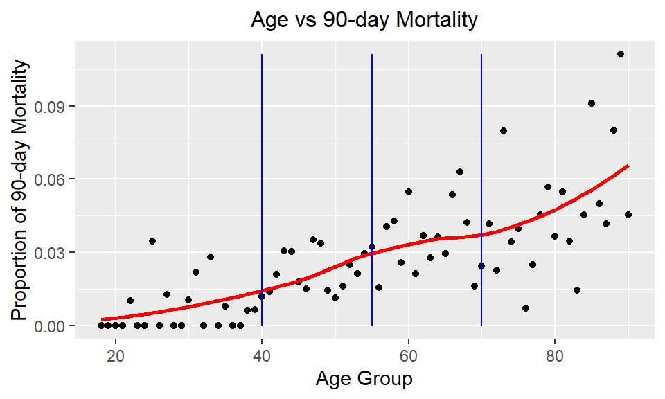

```r
p1 <- grouping(df_all$age)
p1 + geom_line(aes(x=40), color='blue') +
  geom_line(aes(x=55), color='blue') +
  geom_line(aes(x=70), color='blue') +
  labs(title='Age vs 90-day Mortality', x = 'Age Group',
       y='Proportion of 90-day Mortality')+
  theme(legend.position = "none",
        plot.title = element_text(size = 12, hjust = 0.5))
```

The following plots the hospital length of stay variable using the above function:

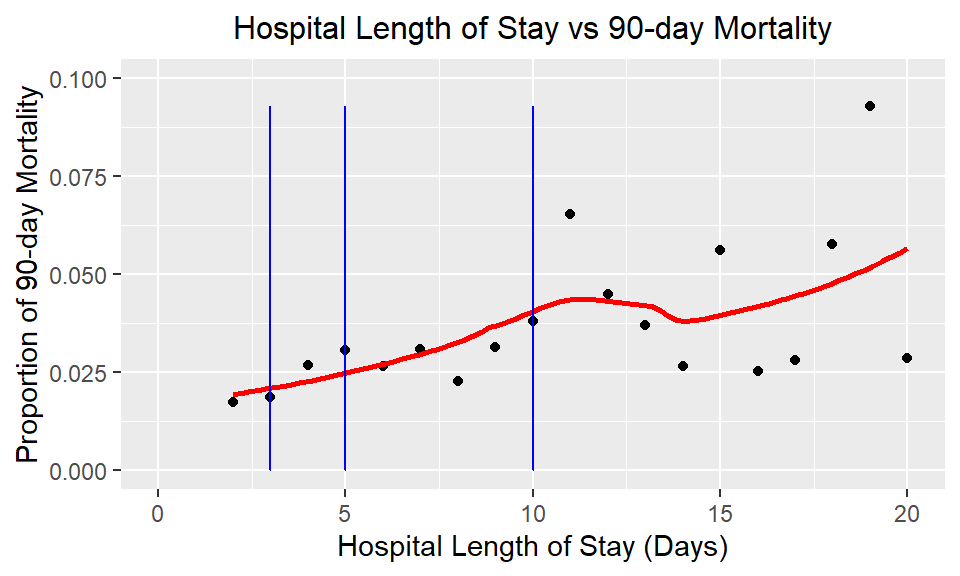

```r
df_all$HOSPITAL_LOS <- as.numeric(df_all$HOSPITAL_LOS, units="days")
p2 <- grouping(df_all$HOSPITAL_LOS)
p2 + geom_line(aes(x=3), color='blue') +
  geom_line(aes(x=5), color='blue') +
  geom_line(aes(x=10), color='blue') +
  xlim(0,20) +
  ylim(0,0.1)+
  labs(title='Hospital Length of Stay vs 90-day Mortality',
       x = 'Hospital Length of Stay (Days)',
       y='Proportion of 90-day Mortality') +
  theme(legend.position = "none",
        plot.title = element_text(size = 12, hjust = 0.5))
```

The following plots the number of reports (doctor’s notes) variable using the above function:

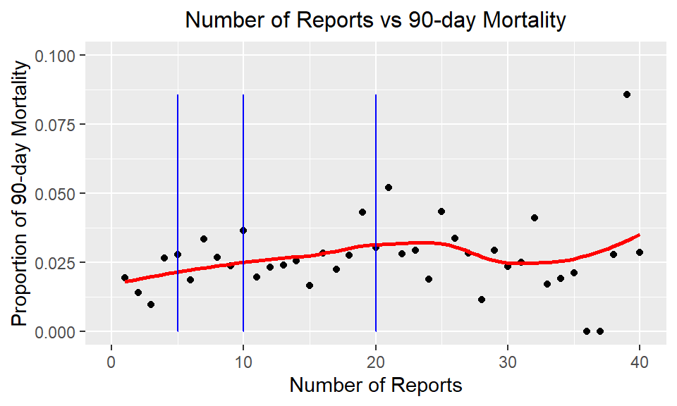

```r
# Impute the NUM_REPORTS column with 0 where Num_reports is missing
df_all$NUM_REPORTS <- ifelse(is.na(df_all$NUM_REPORTS), 0, df_all$NUM_REPORTS)
p3 <- grouping(df_all$NUM_REPORTS)
p3 + geom_line(aes(x=5), color='blue') +
  geom_line(aes(x=10), color='blue') +
  geom_line(aes(x=20), color='blue') +
  xlim(0,40) +
  ylim(0,0.1)+
  labs(title='Number of Reports vs 90-day Mortality',
       x = 'Number of Reports', y='Proportion of 90-day Mortality')+
  theme(legend.position = "none",
        plot.title = element_text(size = 12, hjust = 0.5))
```

The following code converts the numerical variables into categorical according to the plots above.

```r
df_all <- within(df_all,{
  # Bin Age according to MeSH:
  AGE_CAT <- cut(round(age), breaks=c(-Inf,40,55,70, Inf),
                 labels = c("<=40","41-55", "56-70", ">70"))
  # Bin Hospital Length of Stay:
  HOSPITAL_LOS_CAT <- cut(as.numeric(HOSPITAL_LOS), breaks=c(-Inf,3,5,10,Inf),
                          labels = c("2-3","4-5","6-10",">10"))
  # Bin Number of Reports:
  NUM_REPORTS_CAT <- cut(NUM_REPORTS, breaks=c(-Inf,5,10,20, Inf),
                         labels = c("<=5","6-10", "11-20", ">20"))

})
```

The following code re-orders the levels of the new categorical variables:

```r
df_all$HOSPITAL_LOS_CAT = factor(df_all$HOSPITAL_LOS_CAT,
                                 levels = c("2-3","4-5","6-10",">10"))

df_all$NUM_REPORTS_CAT = factor(df_all$NUM_REPORTS_CAT,
                                levels = c("<=5","6-10", "11-20", ">20"))

df_all$AGE_CAT = factor(df_all$AGE_CAT,
                        levels = c("<=40","41-55", "56-70", ">70"))
```

### DATA VISUALIZATION

The following code plots the Hospital Length of Stay vs Event

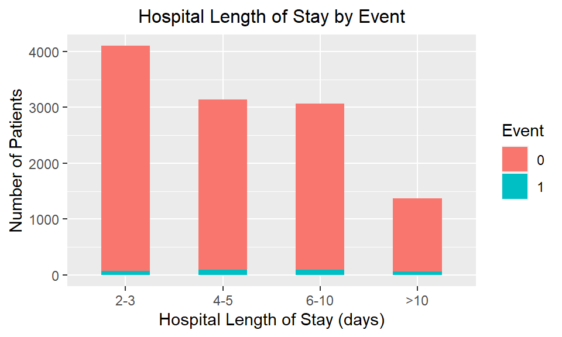

```r
ggplot(df_all) +
  geom_bar(aes(x = HOSPITAL_LOS_CAT, fill = factor(EVENT)),width = 0.5) +
  ggtitle('Hospital Length of Stay by Event') +
  theme(plot.title = element_text(hjust = 0.5, size = 12)) +
  labs(x = 'Hospital Length of Stay (days)', y = 'Number of Patients',
       fill = 'Event')
```

The following code plots the Number of Reports by Event:

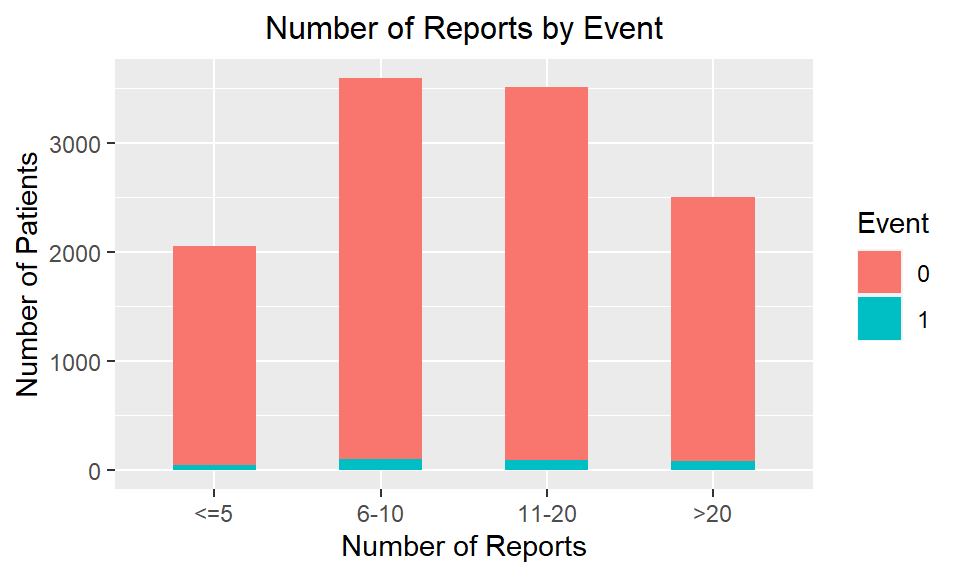

```r
ggplot(df_all) +
  geom_bar(aes(x = NUM_REPORTS_CAT, fill = factor(EVENT)), width = 0.5) +
  ggtitle('Number of Reports by Event') +
  theme(plot.title = element_text(hjust = 0.5, size = 12)) +
  scale_color_discrete(name = 'Event') +
  labs(x = 'Number of Reports', y = 'Number of Patients', fill = 'Event')
```

The following code plots Age by Event:

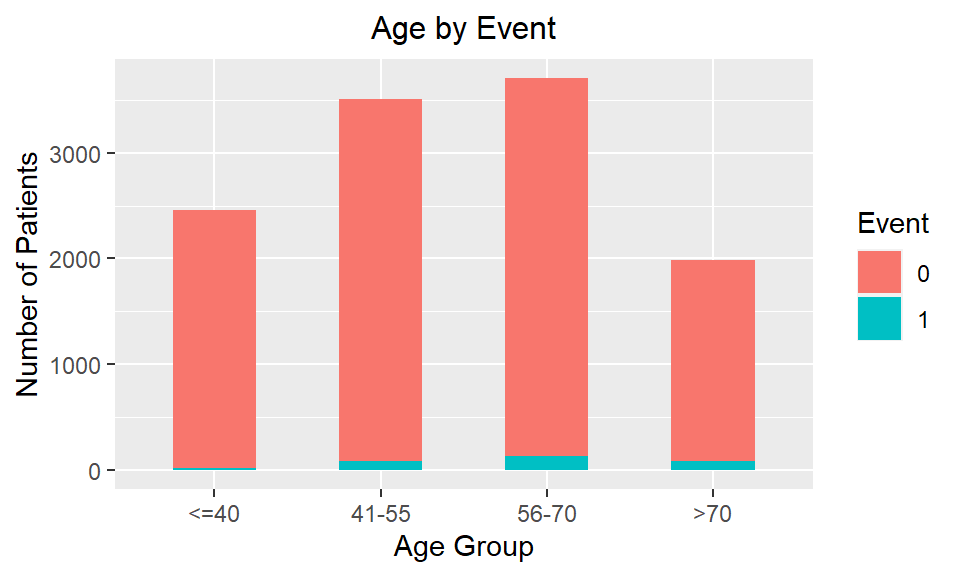

```r
ggplot(df_all) +
  geom_bar(aes(x = AGE_CAT, fill = factor(EVENT)), width = 0.5) +
  ggtitle('Age by Event') +
  theme(plot.title = element_text(hjust = 0.5, size = 12)) +
  scale_color_discrete(name = 'Event') +
  labs(x = 'Age Group', y = 'Number of Patients', fill = 'Event')
```

The following code plots Admission Type by Event:

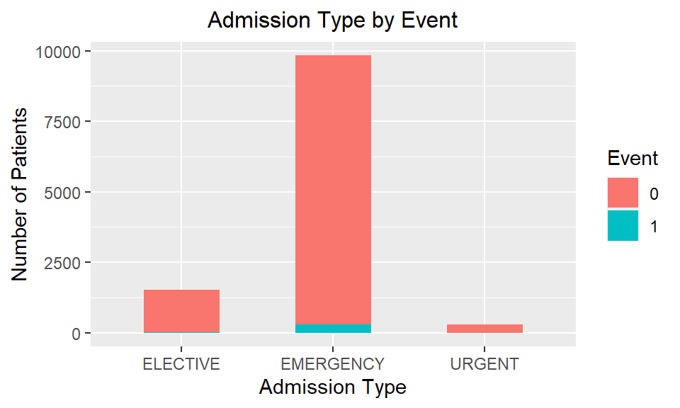

```r
ggplot(df_all) +
  geom_bar(aes(x = ADMISSION_TYPE, fill = factor(EVENT)), width = 0.5) +
  ggtitle('Admission Type by Event') +
  theme(plot.title = element_text(hjust = 0.5, size = 12)) +
  scale_color_discrete(name = 'Event') +
  labs(x = 'Admission Type', y = 'Number of Patients', fill = 'Event')
```

The following code plots MARITAL_STATUS_CAT by Event:

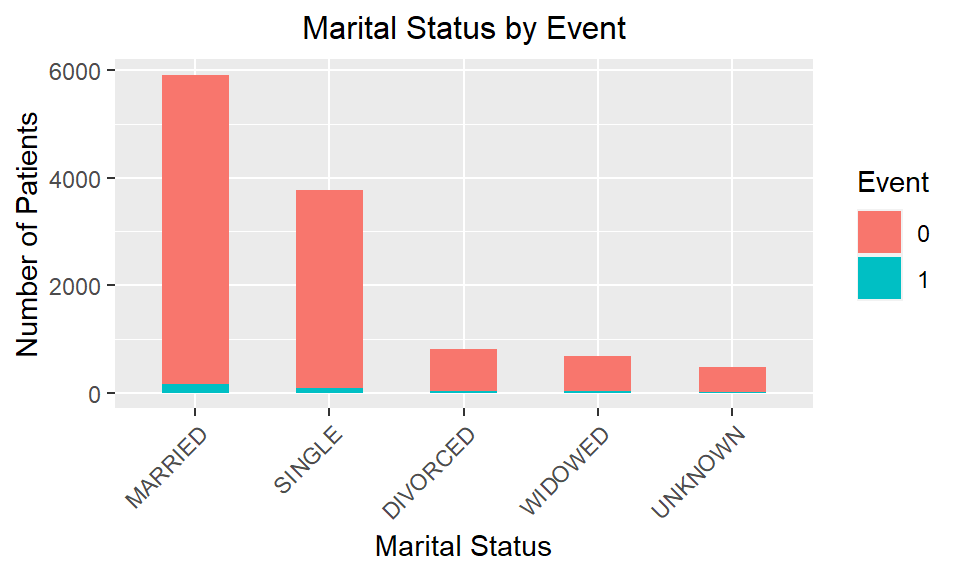

```r
ggplot(df_all) +
  geom_bar(aes(x = MARITAL_STATUS_CAT, fill = factor(EVENT)), width = 0.5) +
  ggtitle('Marital Status by Event') +
  theme(plot.title = element_text(hjust = 0.5, size = 12),
        axis.text.x = element_text(angle = 45, vjust=1, hjust=1)) +
  scale_color_discrete(name = 'Event') +
  labs(x = 'Marital Status', y = 'Number of Patients', fill = 'Event')
```

The following code plots ETHNICITY_CAT by Event:

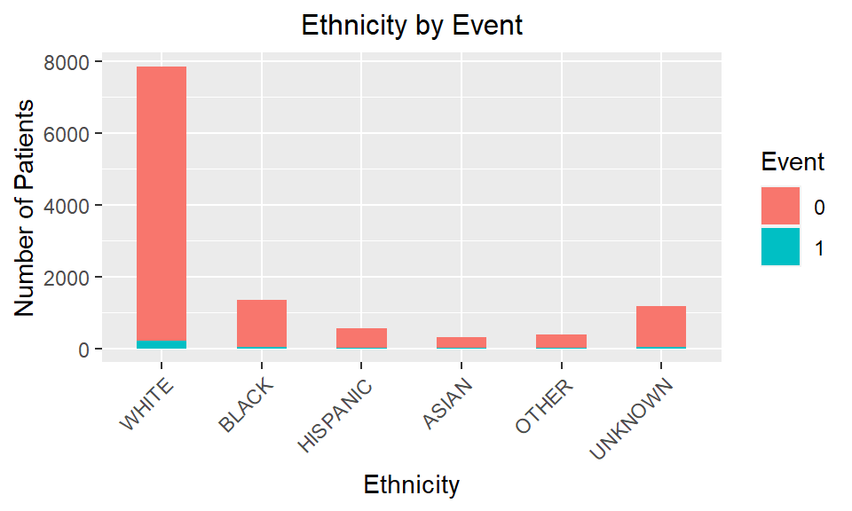

```r
ggplot(df_all) +
  geom_bar(aes(x = ETHNICITY_CAT, fill = factor(EVENT)), width = 0.5) +
  ggtitle('Ethnicity by Event') +
  theme(plot.title = element_text(hjust = 0.5, size = 12),
        axis.text.x = element_text(angle = 45, vjust=1, hjust=1)) +
  scale_color_discrete(name = 'Event') +
  labs(x = 'Ethnicity', y = 'Number of Patients', fill = 'Event')
```

### VITAL SIGN DATA

The following code adds the vital sign data to the cleaned data set in hoping of improving the survival analysis results. The missing values and outliers are detected and treated in the following code. There are missing values in the vital sign data, which is assumed based on domain knowledge to be from patients who were not required to take those measurements. Outliers in the vital sign data are detected by domain knowledge instead of statistical methods. For example, the blood oxygen saturation should not exceed 100, and should not be below 0. There are only a few such outliers, and they are temporarily treated as missing values. The missing values are coded as “Missing”, and the non-missing values are coded into categories such as “Low”, “Normal”, and “High”, where the “Normal” range is based on domain knowledge.

```r
# Select columns that will be used in the survival analysis:
all <- df_all %>%
  select("HADM_ID","ADMISSION_TYPE","LAST_ICU", "GENDER",
         "ami","chf","pvd","cevd","dementia","copd","rheumd","pud","mld",
         "diab","diabwc" ,"hp", "rend","canc","msld","metacanc","aids",
         "Duration", "EVENT","MARITAL_STATUS_CAT", "ETHNICITY_CAT",
         "AGE_CAT","NUM_REPORTS_CAT","HOSPITAL_LOS_CAT")
```

#### BODY TEMERATURE

```r
temperature <- read.csv("Data/Vital_Sign_Data/temperatureFixed.csv")
temperature <- select(temperature, c("HADM_ID","TEMPERATURE_LAST"))

# Merge with the main data set
all_vital <- merge(all, temperature, by="HADM_ID", all.x =TRUE)
```

#### HEART RATE

```r
heart <- read.csv("Data/Vital_Sign_Data/heartRateFixed.csv")
heart <- select(heart, c("HADM_ID","HeartRate_LAST"))

# Merge with the main data set
all_vital <- merge(all_vital, heart, by="HADM_ID", all.x =TRUE)
```

#### OXYGEN SATURATION

```r
oxygen <- read.csv("Data/Vital_Sign_Data/spo2Fixed.csv")
oxygen <- select(oxygen, c("HADM_ID","SpO2_LAST"))

# Merge with the main data set
all_vital <- merge(all_vital, oxygen, by="HADM_ID", all.x =TRUE)
```

#### RESPIROTORY RATE

```r
resp <- read.csv("Data/Vital_Sign_Data/respRateFixed.csv")
resp <- select(resp, c("HADM_ID","RespRate_LAST"))

# Merge with the main data set
all_vital <- merge(all_vital, resp, by="HADM_ID", all.x =TRUE)
```

#### DIASTOLIC BLOOD PRESSURE

```r
diastolic <- read.csv("Data/Vital_Sign_Data/diastolicBPfixed.csv")
diastolic <- select(diastolic, c("HADM_ID","DIASTOLIC_BP_LAST"))

# Merge with the main data set
all_vital <- merge(all_vital, diastolic, by="HADM_ID", all.x =TRUE)
```

#### SYSTOLIC BLOOD PRESSURE

```r
systolic <- read.csv("Data/Vital_Sign_Data/systolicBPfixed.csv")
systolic <- select(systolic, c("HADM_ID","SYSTOLIC_BP_LAST"))

# Merge with the main data set
all_vital <- merge(all_vital, systolic, by="HADM_ID", all.x =TRUE)
```

#### HANDLING MISSING VALUES IN VITAL SIGN DATA

The following code plot the number of missing values in each of the six vital sign variables.

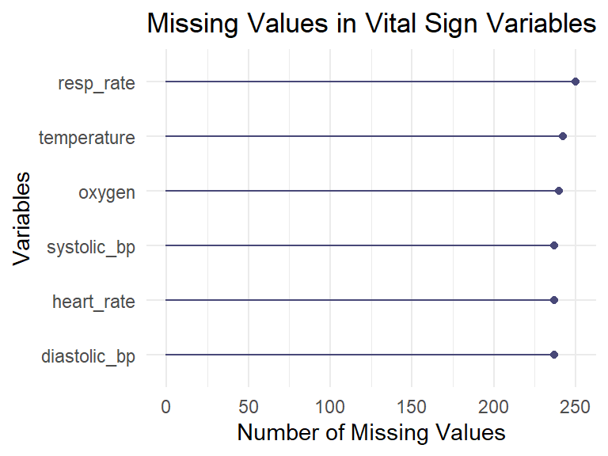

```r
names(all_vital)[29:34] = c("temperature","heart_rate","oxygen","resp_rate",
                            "diastolic_bp", "systolic_bp" )

# Plot
gg_miss_var(all_vital[,29:34])+
  labs(y = "Number of Missing Values",
       title = "Missing Values in Vital Sign Variables")
```

The following code plot the location of the missing values in each of the six vital sign variables with the percentage of missing values at the bottom of the plot.

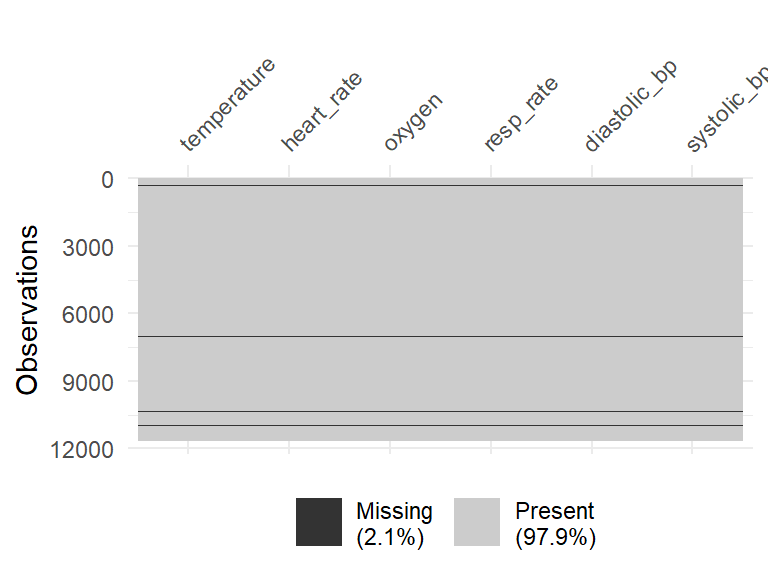

```r
vis_miss(all_vital[,29:34], show_perc_col = FALSE)
```

The following code groups vital sign data into categories, where outliers are temporarily treated as missing values. The cut off values are based on domain knowledge.

```r
all_vital_clean <- all_vital %>%
  mutate(temperature_cat = case_when(
    is.na(temperature) == TRUE   ~ 'Missing',
    temperature <= 0             ~ 'Missing',
    temperature < 36.5           ~ 'Low',
    temperature <= 37.5          ~ 'Normal',
    TRUE                              ~ 'High'),
    heart_cat = case_when(
      is.na(heart_rate) == TRUE   ~ 'Missing',
      heart_rate <= 0             ~ 'Missing',
      heart_rate < 60             ~ 'Low',
      heart_rate <= 100           ~ 'Normal',
      heart_rate <= 300           ~ 'High',
      TRUE                        ~ 'Missing'),
    oxygen_cat = case_when(
      is.na(oxygen) == TRUE   ~ 'Missing',
      oxygen <= 0             ~ 'Missing',
      oxygen < 90             ~ 'VeryLow',
      oxygen <= 94            ~ 'Low',
      oxygen <= 100           ~ 'Normal',
      TRUE                    ~ 'Missing'),
    resp_cat = case_when(
      is.na(resp_rate) == TRUE   ~ 'Missing',
      resp_rate <= 0             ~ 'Missing',
      resp_rate < 12             ~ 'Low',
      resp_rate <= 25            ~ 'Normal',
      TRUE                       ~ 'High'),
    diastolic_cat = case_when(
      is.na(diastolic_bp) == TRUE   ~ 'Missing',
      diastolic_bp <= 0             ~ 'Missing',
      diastolic_bp < 60             ~ 'Low',
      diastolic_bp <= 80            ~ 'Normal',
      TRUE                          ~ 'High'),
    systolic_cat = case_when(
      is.na(systolic_bp) == TRUE   ~ 'Missing',
      systolic_bp <= 0             ~ 'Missing',
      systolic_bp < 90             ~ 'Low',
      systolic_bp <= 120           ~ 'Normal',
      TRUE                         ~ 'High')
    )
```

The following code re-orders the levels of the new categorical vital sign variables, and deletes the original variables。

```r
all_vital_clean <- all_vital_clean %>%
  mutate(
  temperature_cat = factor(temperature_cat, levels = c("Normal", "Low", "High", "Missing")),
  heart_cat = factor(heart_cat, levels = c("Normal", "Low", "High", "Missing")),
  oxygen_cat = factor(oxygen_cat, levels = c("Normal", "VeryLow", "Low", "High", "Missing")),
  resp_cat = factor(resp_cat, levels = c("Normal", "Low", "High", "Missing")),
  diastolic_cat = factor(diastolic_cat, levels = c("Normal", "Low", "High", "Missing")),
  systolic_cat = factor(systolic_cat, levels = c("Normal", "Low", "High", "Missing")),
  temperature = NULL,
  heart_rate = NULL,
  oxygen = NULL,
  resp_rate = NULL,
  diastolic_bp = NULL,
  systolic_bp = NULL,
  ADMISSION_TYPE = factor(ADMISSION_TYPE),
  LAST_ICU = factor(LAST_ICU),
  GENDER = factor(GENDER)
)
```

### COX PROPORTIONAL HAZARD SURVIVAL ANALYSIS

The following code performs the Cox Proportional Hazard survival analysis.

```r
# Create the time and event variables as required in the cox model
time <- all_vital_clean$Duration
event <- all_vital_clean$EVENT
x <- select(all_vital_clean, -c(HADM_ID, Duration, EVENT))
names(x) <- tolower(names(x))

coxph <- coxph(Surv(time,event) ~ ., data = x)
summary(coxph)
```

```
## Call:
## coxph(formula = Surv(time, event) ~ ., data = x)
##
##   n= 11666, number of events= 311
##
##                                  coef  exp(coef)   se(coef)      z Pr(>|z|)
## admission_typeEMERGENCY     1.122e+00  3.070e+00  2.628e-01  4.268 1.97e-05 ***
## admission_typeURGENT        6.317e-01  1.881e+00  5.181e-01  1.219 0.222726
## last_icuCSRU               -4.068e-01  6.658e-01  3.112e-01 -1.307 0.191087
## last_icuMICU               -1.089e-01  8.968e-01  1.673e-01 -0.651 0.515126
## last_icuSICU               -3.000e-01  7.408e-01  2.166e-01 -1.385 0.166064
## last_icuTSICU              -8.199e-01  4.405e-01  3.320e-01 -2.469 0.013534 *
## genderM                     2.217e-01  1.248e+00  1.310e-01  1.692 0.090690 .
## ami                        -1.102e-01  8.957e-01  1.836e-01 -0.600 0.548586
## chf                         5.635e-01  1.757e+00  1.433e-01  3.933 8.38e-05 ***
## pvd                         4.314e-01  1.539e+00  2.106e-01  2.048 0.040511 *
## cevd                       -5.979e-02  9.420e-01  2.581e-01 -0.232 0.816777
## dementia                    8.046e-01  2.236e+00  7.316e-01  1.100 0.271428
## copd                        1.735e-01  1.189e+00  1.399e-01  1.240 0.215140
## rheumd                      9.138e-02  1.096e+00  3.648e-01  0.251 0.802186
## pud                         2.757e-02  1.028e+00  2.800e-01  0.098 0.921560
## mld                         1.919e-01  1.212e+00  2.057e-01  0.933 0.350892
## diab                       -2.117e-02  9.791e-01  1.472e-01 -0.144 0.885637
## diabwc                      2.097e-01  1.233e+00  2.324e-01  0.902 0.366928
## hp                          1.023e+00  2.783e+00  4.651e-01  2.200 0.027779 *
## rend                        4.371e-01  1.548e+00  1.578e-01  2.769 0.005618 **
## canc                        1.039e+00  2.825e+00  1.548e-01  6.709 1.95e-11 ***
## msld                        1.190e+00  3.288e+00  2.360e-01  5.044 4.56e-07 ***
## metacanc                    1.847e+00  6.342e+00  1.653e-01 11.177  < 2e-16 ***
## aids                        4.137e-01  1.512e+00  3.970e-01  1.042 0.297406
## marital_status_catSINGLE    2.623e-01  1.300e+00  1.435e-01  1.828 0.067595 .
## marital_status_catDIVORCED  3.049e-01  1.357e+00  2.223e-01  1.372 0.170135
## marital_status_catWIDOWED   2.372e-01  1.268e+00  2.359e-01  1.006 0.314593
## marital_status_catUNKNOWN   4.284e-01  1.535e+00  3.333e-01  1.286 0.198595
## ethnicity_catBLACK          2.016e-01  1.223e+00  1.901e-01  1.060 0.288971
## ethnicity_catHISPANIC      -3.460e-01  7.075e-01  3.441e-01 -1.005 0.314685
## ethnicity_catASIAN          2.623e-01  1.300e+00  2.957e-01  0.887 0.375168
## ethnicity_catOTHER         -2.511e-01  7.780e-01  3.635e-01 -0.691 0.489760
## ethnicity_catUNKNOWN        2.395e-01  1.271e+00  2.225e-01  1.076 0.281829
## age_cat41-55                9.880e-01  2.686e+00  2.813e-01  3.512 0.000444 ***
```

[output cut: 82 more lines]

```
## oxygen_catMissing          2.863e-01  3.492e+00  0.004581   17.8990
## resp_catLow                6.703e-01  1.492e+00  0.387399    1.1599
## resp_catHigh               1.088e+00  9.193e-01  0.746880    1.5841
## resp_catMissing            5.900e-01  1.695e+00  0.193163    1.8023
## diastolic_catLow           1.151e+00  8.685e-01  0.868347    1.5267
## diastolic_catHigh          1.120e+00  8.932e-01  0.816318    1.5354
## diastolic_catMissing       7.051e+04  1.418e-05  0.000000       Inf
## systolic_catLow            1.206e+00  8.295e-01  0.668359    2.1744
## systolic_catHigh           9.058e-01  1.104e+00  0.695952    1.1790
## systolic_catMissing        4.591e-05  2.178e+04  0.000000       Inf
##
## Concordance= 0.835  (se = 0.011 )
## Likelihood ratio test= 533.9  on 60 df,   p=<2e-16
## Wald test            = 615.6  on 60 df,   p=<2e-16
## Score (logrank) test = 836.2  on 60 df,   p=<2e-16
```

The following code saves the summary of the output of the coxph model with all variables to the results folder.

```r
sink(file = 'Results/home_all_vars.txt')
summary(coxph)
sink(file=NULL)
```

The following code removes all insignificant variables and then reruns the model.

```r
x <- select(x, -c(ami, cevd, dementia, copd,rheumd, pud, mld, aids,diab,diabwc,
                  ethnicity_cat, num_reports_cat,heart_cat,oxygen_cat,
                  diastolic_cat, systolic_cat,resp_cat,gender))

coxph <- coxph(Surv(time,event) ~ ., data = x)
summary(coxph)
```

```
## Call:
## coxph(formula = Surv(time, event) ~ ., data = x)
##
##   n= 11666, number of events= 311
##
##                                coef exp(coef) se(coef)      z Pr(>|z|)
## admission_typeEMERGENCY     1.12656   3.08501  0.25900  4.350 1.36e-05 ***
## admission_typeURGENT        0.64227   1.90079  0.51419  1.249 0.211627
## last_icuCSRU               -0.44579   0.64032  0.30434 -1.465 0.142985
## last_icuMICU               -0.05475   0.94672  0.15426 -0.355 0.722642
## last_icuSICU               -0.33861   0.71276  0.20484 -1.653 0.098320 .
## last_icuTSICU              -0.89357   0.40919  0.32475 -2.752 0.005932 **
## chf                         0.59267   1.80881  0.13932  4.254 2.10e-05 ***
## pvd                         0.39424   1.48325  0.20631  1.911 0.056023 .
## hp                          0.99063   2.69294  0.45838  2.161 0.030685 *
## rend                        0.49933   1.64761  0.14628  3.414 0.000641 ***
## canc                        1.06837   2.91063  0.15216  7.021 2.20e-12 ***
## msld                        1.31447   3.72276  0.17383  7.562 3.97e-14 ***
## metacanc                    1.79210   6.00202  0.16115 11.121  < 2e-16 ***
## marital_status_catSINGLE    0.28407   1.32852  0.13887  2.046 0.040799 *
## marital_status_catDIVORCED  0.29954   1.34924  0.21884  1.369 0.171063
## marital_status_catWIDOWED   0.12981   1.13861  0.22797  0.569 0.569064
## marital_status_catUNKNOWN   0.46636   1.59419  0.31528  1.479 0.139084
## age_cat41-55                0.96904   2.63541  0.27929  3.470 0.000521 ***
## age_cat56-70                1.19797   3.31338  0.27811  4.308 1.65e-05 ***
## age_cat>70                  1.44155   4.22725  0.29557  4.877 1.08e-06 ***
## hospital_los_cat4-5         0.36215   1.43642  0.15877  2.281 0.022549 *
## hospital_los_cat6-10        0.32191   1.37977  0.16148  1.994 0.046205 *
## hospital_los_cat>10         0.82885   2.29068  0.18045  4.593 4.36e-06 ***
## temperature_catLow          0.36163   1.43567  0.12301  2.940 0.003283 **
## temperature_catHigh        -0.03117   0.96931  0.22540 -0.138 0.890019
## temperature_catMissing     -0.11602   0.89046  0.45582 -0.255 0.799094
## ---
## Signif. codes:  0 '***' 0.001 '**' 0.01 '*' 0.05 '.' 0.1 ' ' 1
##
##                            exp(coef) exp(-coef) lower .95 upper .95
## admission_typeEMERGENCY       3.0850     0.3241    1.8569    5.1253
## admission_typeURGENT          1.9008     0.5261    0.6938    5.2073
## last_icuCSRU                  0.6403     1.5617    0.3526    1.1627
## last_icuMICU                  0.9467     1.0563    0.6997    1.2809
```

[output cut: 12 more lines]

```
## marital_status_catUNKNOWN     1.5942     0.6273    0.8594    2.9574
## age_cat41-55                  2.6354     0.3794    1.5245    4.5560
## age_cat56-70                  3.3134     0.3018    1.9211    5.7147
## age_cat>70                    4.2273     0.2366    2.3685    7.5448
## hospital_los_cat4-5           1.4364     0.6962    1.0523    1.9608
## hospital_los_cat6-10          1.3798     0.7248    1.0054    1.8935
## hospital_los_cat>10           2.2907     0.4366    1.6083    3.2626
## temperature_catLow            1.4357     0.6965    1.1281    1.8271
## temperature_catHigh           0.9693     1.0317    0.6232    1.5077
## temperature_catMissing        0.8905     1.1230    0.3644    2.1758
##
## Concordance= 0.829  (se = 0.011 )
## Likelihood ratio test= 505.8  on 26 df,   p=<2e-16
## Wald test            = 588.1  on 26 df,   p=<2e-16
## Score (logrank) test = 810  on 26 df,   p=<2e-16
```

The following code saves the summary of the output of the coxph model with significant variables only to the results folder.

```r
sink(file = 'Results/home_sig.txt')
summary(coxph)
sink(file=NULL)
```

The following code plots the hazard ratio.

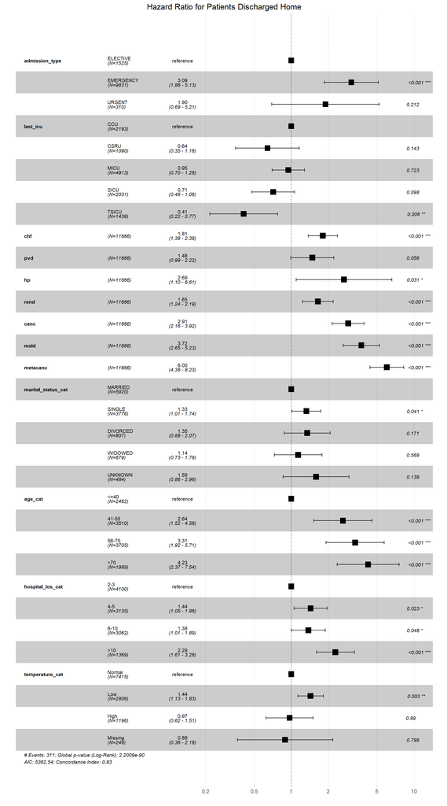

```r
ggforest(coxph, data = x, main="Hazard Ratio for Patients Discharged Home", fontsize = 0.7)
```

The following code saves the plot to the Results folder.

```r
tiff(file="Results/plot_hazard_ratio_home.tiff",
     width=10, height=15, units="in", res=300)
ggforest(coxph, data = x, main="Hazard Ratio for Patients Discharged Home", fontsize = 0.7)
dev.off()
```